# ICCONIC HipFX time to surgery: Analytical pipeline

Author

Data Science for Health Services and Policy Research (IACS)

Analysis version: 1.1.2

# Introduction

Breaking a hip might be a sign of frailty. It can entail diminished autonomy and a high risk of death in the elderly (i.e. 30% dying within a year, with 7% dying during hospitalization). With the ageing population, hip fractures in the elderly are becoming a growing medical and social concern as it lead to frailty, decreasing autonomy, worse quality of life or even death.

In hip fracture care, whether mortality worsens when surgery is delayed is disputed. Proponents of early surgery believe that there is decreased morbidity with early fixation and reduced mortality with early mobilization postoperatively. Proponents of elective surgery argue that most elderly require vascular stabilization, including reversion of antiplatelet or anticoagulant therapies to minimize bleeding during hip surgery, resulting in better quality of care and, ultimately, better outcomes.

Key elements of the acute treatment of hip fracture in the elderly (frailty) population imply health care capacity and processes in weighting the individual situation of each patient in terms of prognosis, concurrent clinical conditions, medication, autonomy and self-care ability, and social circumstances in the indication of surgery with the expectation for the patient returning home. Mortality in hip fracture patients after surgery can be a critical indicator in benchmarking hospital performance in assisting the elderly and frail population.

This preliminary evidence is consistent with literature focusing on the type of surgery and the management of anti-aggregated or anticoagulated patients - rather than on time-to-surgery - as the main predictors of adverse outcomes.

However, the evidence from ICCONIC is based on aggregated information that might suffer from some biases. Taking advantage of the ICCONIC collaborative at (https://www.lse.ac.uk/lse-health/research/projects/ICCONIC) and (https://icconic.org/), we will explore the variation in inpatient, 7-day mortality and 30-day mortality after hip fracture surgery across ICCONIC hospitals, using individual-level data, taking into consideration the differences in surgical and perioperative management as well as health system differences. In addition, we will examine patterns of polypharmacy, high-risk prescribing, and medication review before and after hip fracture. Subsequently, we will determine hip fracture outcomes depending on socioeconomic factors. This study aims to measure mortality after hip fracture surgery as a benchmark for hospital performance across several countries, considering patients’, hospitals’ and contextual factors that might contribute to better outcomes, including time-to-surgery, comorbidities and previous therapies.

# Hypothesis

The study’s central hypothesis explores whether hospital performance in terms of mortality after surgery worsens when the intervention is delayed after a hip fracture in a population over 65.

# Objectives

## General objective

Determinate that prompt action in the acute treatment of hip fracture in the elderly (frailty) population implies health care capacity and processes in weighting the individual situation of each patient in terms of prognosis, concurrent clinical conditions, medication, autonomy and self-care ability, and social circumstances in the indication of surgery with the expectation for the patient returning home.

### Specific Objectives

1. Evaluate the impact of time to hip surgery after fracture on mortality
2. Determinate hip fracture outcomes depending on socioeconomic factors

# Methodology

## Design

An observational retrospective longitudinal multi-country cohort study of individuals aged 65+ admitted to a hospital due to hip fracture that underwent hip pinning or replacement surgery between 01-01-2017 and 31-12-2021.  
The cohort to be studied includes any person 65 years old or older, with an unplanned hospital episode (inpatient), with a primary diagnosis of hip fracture, with the following exclusion criteria: a) any person under 65 years old, b) multiple fractures (polytrauma), or c) admission from another hospital. To determine hip fracture outcomes depending on socioeconomic factors would be supplemented with analyses by socio-economic status. The study will be conducted simultaneously in Spain (Aragón), the USA (Brown University), and several other countries (i.e., Denmark, Finland, Canada, and Sweden), following a federated research methodology based mainly on the reuse of healthcare data from administrative databases at regional or population level at each country.

## Information sources

The analyses are based on Individual-level data from health records (i.e., electronic medical records) and administrative data (information on hospital discharges). Data will be analysed locally by each of the participants using deployable analytical scripts. The participants will then share aggregated outputs of the local analyses to conduct a meta-analysis comparing hospitals’ performance in the different countries. In Aragon, data will be requested from BIGAN (established by Executive Order SAN/1355/2018 as an element of the health information system in Aragon). Each participant will comply with their institution’s data application processes to access and process data for research.

## Population studied

All the population insured in Aragon with a relevant contact with the healthcare system during the study period.

## Relevant outcomes

*Adjusted inpatient mortality by hospital:* adjusted mortality after surgery due to hip fracture occurring in the index hospital episode considering patient attributes (i.e., age, sex, comorbidities, etc.), care process (i.e. time to surgery, month, weekday, etc.), and contextual data (i.e., socioeconomic data of the area of residence of the patient, etc.)

*7-day adjusted mortality:* adjusted mortality up to 7 days after surgery due to hip fracture considering patient attributes (i.e., age, sex, comorbidities, etc.), care process (i.e. time to surgery, month, weekday, etc.), and contextual data (i.e., socioeconomic data of the area of residence of the patient, etc.)

*30-day adjusted mortality:* adjusted mortality up to 30 days after surgery due to hip fracture considering patient attributes (i.e., age, sex, comorbidities, etc.), care process (i.e. time to surgery, month, weekday, etc.), and contextual data (i.e., socioeconomic data of the area of residence of the patient, etc.)

*7-day unplanned readmission:* adjusted unplanned readmission (for any cause) up to 7 days after hospitalization due to hip fracture considering patient attributes (i.e., age, sex, comorbidities, etc.), care process (i.e. time to surgery, month, weekday, etc.), and contextual data (i.e., socioeconomic data of the area of residence of the patient, etc.)

*30-day unplanned readmission:* adjusted unplanned readmission (for any cause) up to 30 days after hospitalization due to hip fracture considering patient attributes (i.e., age, sex, comorbidities, etc.), care process (i.e. time to surgery, month, weekday, etc.), and contextual data (i.e., socioeconomic data of the area of residence of the patient, etc.)

## Variables of the study

You can see in **docs/CDM** folder the specification of the common data model and cohort selection criteria, including the description of the study’s variables.

## Statistical Analysis

### Data quality analysis on local inputs

Local analyses will be preceded by a data quality and validation analysis on local inputs at the origin. Those analyses will consist of univariate exploratory data analysis of each of the variables of the data entities required for the study and information on the compliance of the local input data with the data validation rules established by the common data model specification.

### Descriptive statistics

Local analysis will include descriptive statistics at the individual level on patient and episode characteristics and prescriptions before and after hospital admission due to hip fracture and on the characteristics of patients admitted and intervened in each hospital.

### Modelling hospital performance

#### Adjusted mortality by time to surgery

In order to study whether there is a relationship between mortality and the time elapsed between the date of admission and the date of surgery, two different groups of models depending on the number of independent variables are carried out. On the one hand, several reference univariate models. On the other hand, several multivariate models.

##### Adjusted mortality by time to surgery (univariate models)

Four different univariate models are built:

1. Generalized Linear Model (GLM): three GLM models following the same methodology but varying the dependent variable (y):
   - Model 1: y = inpatient mortality due to any cause
   - Model 2: y = mortality 7-days after surgery (any cause)
   - Model 3: y = mortality 30-days after surgery (any cause)

In this model, the independent variable (x) is the time elapsed between the date of admission and the date of surgery categorized as:

```
- 1: x <= 24 hours

- 2: 24 hours < x <= 48 hours

- 3: 48 hours < x <= 72 hours

- 4: 72 hours < x
```

##### Adjusted mortality by time to surgery (multivariate models)

Three multilevel GAMM models are built depending on the dependent variable to be predicted (y) as previous section. The most relevant independent variable in this case is (as previous section) the time elapsed between the date of admission and the date of surgery but in this case different patient variables that are considered relevant in the study such as age, sex, comorbidities etc. are introduced into the model.

#### Adjusted unplanned readmissions by time to surgery (multivariate models)

In order to study whether there is a relationship between unplanned readmissions and the time elapsed between the date of admission and the date of surgery, two multivariate GAMM models are carried out

```
- Model 1: y = unplanned readmission (for any cause) in the next 7 days after hospitalization

- Model 2: y = unplanned readmission (for any cause) in the next 30 days after hospitalization
```

### International hospital performance comparison (meta-analysis)

A meta-regression will be adjusted considering region or country-level contextual factors using the aggregated local output data on hospital performance as the primary input. The international comparison meta-analysis will compare hospital performance across the country/regions participating in the study, enabling ranking and providing information on the overall association of healthcare behaviour, namely time-to-surgery on mortality after surgery for hip fracture.

# Results (ESP)

## Descriptive statistics

The following are shown 2 descriptive tables of the imported data:

- Table 1 shows the main characteristics of the patients registered in the database.
- Table 2 main characteristics of the patients and the medians from admission to surgery (in days) and their interquartile range grouped by hospital.

### Table 1. Patient-level summary

Patient-level summary

| Variable | n (%) |
| --- | --- |
| Country cd | ESP |
| Median age | 83 |
| IQR age | 19 |
| N patients (unique) | 10000 |
| N hospitalization episode (unique) | 10000 |
| N patient with surgery (unique) | 7497 |
| Median time from admission to surgery (days) | 4 |
| IQR time from admission to surgery (days) | 5 |
| N Men (%) | 4922 (49.22%) |
| N Women (%) | 4887 (48.87%) |

Socioeconomic level table input

|  | n (%) |
| --- | --- |
| Socioeconomic lvl: 1 | 214 (2.14%) |
| Socioeconomic lvl: 2 | 1326 (13.26%) |
| Socioeconomic lvl: 3 | 3689 (36.89%) |
| Socioeconomic lvl: 4 | 3398 (33.98%) |
| Socioeconomic lvl: 5 | 1373 (13.73%) |

Surgical procedure table input

|  | n (%) |
| --- | --- |
| Total | 496 (4.96%) |
| Partial | 318 (3.18%) |
| Pinning | 726 (7.26%) |
| Other | 5957 (59.57%) |
| Non surgical procedure | 2503 (25.03%) |

Anesthesia type table input

|  | n (%) |
| --- | --- |
| General | 2287 (30.51%) |
| Locorregional | 2288 (30.52%) |
| Locorregional and General | 2202 (29.37%) |
| Unknown | 720 (9.6%) |

Number of comorbidities table input

|  | n (%) |
| --- | --- |
| <= 2 N comorbidities | 5990 (59.9%) |
| 3 <= N comorbidities <= 5 | 3791 (37.91%) |
| 5 < N comorbidities | 219 (2.19%) |

### Table 2. Hospital-level summary

Hospital-level summary

| Hospital | N patients (unique) | N hospitalization episode (unique) | N patient with surgery (unique) | Median age | IQR age | N Women | Median time from admission to surgery (days) | IQR time from admission to surgery (days) | N exitus (all) | N unplanned readmission 30 days (unique) |
| --- | --- | --- | --- | --- | --- | --- | --- | --- | --- | --- |
| NvnAvO | 1014 | 1014 | 744 | 82 | 20 | 493 | 4 | 5 | 134 | 113 |
| ppgrVk | 1023 | 1023 | 764 | 83 | 19 | 490 | 4 | 5 | 162 | 106 |
| FVYySn | 1003 | 1003 | 764 | 83 | 19 | 500 | 4 | 5 | 155 | 95 |
| PxeqAW | 992 | 992 | 751 | 82 | 19 | 488 | 4 | 5 | 140 | 107 |
| mqTjDm | 988 | 988 | 750 | 82 | 18 | 479 | 4 | 5 | 146 | 91 |
| fdSrDs | 999 | 999 | 735 | 83 | 19 | 485 | 4 | 5 | 156 | 90 |
| GnVZQU | 1007 | 1007 | 733 | 82 | 20 | 482 | 4 | 4 | 127 | 108 |
| eRKOGF | 965 | 965 | 730 | 83 | 18 | 463 | 4 | 4 | 133 | 94 |
| YsUlhh | 1007 | 1007 | 759 | 82 | 20 | 490 | 4 | 5 | 131 | 84 |
| xFuDpj | 1002 | 1002 | 767 | 84.5 | 19.75 | 517 | 4 | 5 | 129 | 94 |

## Hospital performance

### Models

#### Adjusted mortality by time to surgery

##### Adjusted mortality by time to surgery (univariate models)

###### Generalized Linear Model (GLM)

**Model with variable to predict: exitus in hospital**

```
Call:
glm(formula = exitus_hosp_bl ~ futime_adm_surg_cd, family = binomial(link = "logit"),
    data = df_model, method = "glm.fit")

Coefficients:
                          Estimate Std. Error z value Pr(>|z|)
(Intercept)               -1.95445    0.07555 -25.869   <2e-16 ***
futime_adm_surg_cd24h-48h  0.25158    0.11773   2.137   0.0326 *
futime_adm_surg_cd48h-72h  0.21474    0.11928   1.800   0.0718 .
futime_adm_surg_cd>=72h    0.16211    0.08798   1.843   0.0654 .
---
Signif. codes:  0 '***' 0.001 '**' 0.01 '*' 0.05 '.' 0.1 ' ' 1

(Dispersion parameter for binomial family taken to be 1)

    Null deviance: 6098.9  on 7496  degrees of freedom
Residual deviance: 6093.0  on 7493  degrees of freedom
AIC: 6101

Number of Fisher Scoring iterations: 4
```

**Model with variable to predict: exitus in 7 days after surgery**

```
Call:
glm(formula = exitus_7days_bl ~ futime_adm_surg_cd, family = binomial(link = "logit"),
    data = df_model, method = "glm.fit")

Coefficients:
                          Estimate Std. Error z value Pr(>|z|)
(Intercept)                -3.4625     0.1451 -23.867   <2e-16 ***
futime_adm_surg_cd24h-48h   0.0492     0.2355   0.209    0.835
futime_adm_surg_cd48h-72h   0.1348     0.2311   0.583    0.560
futime_adm_surg_cd>=72h    -0.1177     0.1746  -0.674    0.500
---
Signif. codes:  0 '***' 0.001 '**' 0.01 '*' 0.05 '.' 0.1 ' ' 1

(Dispersion parameter for binomial family taken to be 1)

    Null deviance: 1986.1  on 7496  degrees of freedom
Residual deviance: 1984.2  on 7493  degrees of freedom
AIC: 1992.2

Number of Fisher Scoring iterations: 6
```

**Model with variable to predict: exitus in 30 days after surgery**

```
Call:
glm(formula = exitus_30days_bl ~ futime_adm_surg_cd, family = binomial(link = "logit"),
    data = df_model, method = "glm.fit")

Coefficients:
                          Estimate Std. Error z value Pr(>|z|)
(Intercept)               -2.70541    0.10277 -26.324   <2e-16 ***
futime_adm_surg_cd24h-48h  0.34292    0.15515   2.210   0.0271 *
futime_adm_surg_cd48h-72h  0.21933    0.16068   1.365   0.1723
futime_adm_surg_cd>=72h    0.05429    0.12084   0.449   0.6532
---
Signif. codes:  0 '***' 0.001 '**' 0.01 '*' 0.05 '.' 0.1 ' ' 1

(Dispersion parameter for binomial family taken to be 1)

    Null deviance: 3767.8  on 7496  degrees of freedom
Residual deviance: 3761.4  on 7493  degrees of freedom
AIC: 3769.4

Number of Fisher Scoring iterations: 5
```

###### Generalized Linear Mixed Model (GLMM)

**Model with variable to predict: exitus in hospital**

```
Generalized linear mixed model fit by maximum likelihood (Laplace
  Approximation) [glmerMod]
 Family: binomial  ( logit )
Formula: exitus_hosp_bl ~ futime_adm_surg_cd + (1 | hospital_st)
   Data: df_model_filter

     AIC      BIC   logLik deviance df.resid
  5578.8   5612.9  -2784.4   5568.8     6772

Scaled residuals:
    Min      1Q  Median      3Q     Max
-0.4527 -0.4184 -0.4045 -0.3796  2.6735

Random effects:
 Groups      Name        Variance Std.Dev.
 hospital_st (Intercept) 0.003357 0.05794
Number of obs: 6777, groups:  hospital_st, 10

Fixed effects:
                          Estimate Std. Error z value Pr(>|z|)
(Intercept)                -1.9316     0.0808 -23.906   <2e-16 ***
futime_adm_surg_cd24h-48h   0.2989     0.1214   2.462   0.0138 *
futime_adm_surg_cd48h-72h   0.2298     0.1240   1.854   0.0638 .
futime_adm_surg_cd>=72h     0.1412     0.0919   1.536   0.1244
---
Signif. codes:  0 '***' 0.001 '**' 0.01 '*' 0.05 '.' 0.1 ' ' 1

Correlation of Fixed Effects:
            (Intr) f___24 f___48
ftm___24-48 -0.631
ftm___48-72 -0.618  0.412
ftm_d__>=72 -0.834  0.555  0.544
```

```
[1] "ICC ajusted: 0.00102 with lower_ci95=-0.01687 and upper_ci95=0.01829"
```

```
[1] "Median odds ratio (MOR): 1.05682"
```

```
[1] "MOR with bootsrapping: 1.06039 with lower_ci95=1.03071 and upper_ci95=1.09686"
```

**Model with variable to predict: exitus in 7 days after surgery**

```
Generalized linear mixed model fit by maximum likelihood (Laplace
  Approximation) [glmerMod]
 Family: binomial  ( logit )
Formula: exitus_7days_bl ~ futime_adm_surg_cd + (1 | hospital_st)
   Data: df_model_filter

     AIC      BIC   logLik deviance df.resid
  1839.0   1873.1   -914.5   1829.0     6772

Scaled residuals:
    Min      1Q  Median      3Q     Max
-0.1929 -0.1783 -0.1685 -0.1685  5.9363

Random effects:
 Groups      Name        Variance Std.Dev.
 hospital_st (Intercept) 0        0
Number of obs: 6777, groups:  hospital_st, 10

Fixed effects:
                          Estimate Std. Error z value Pr(>|z|)
(Intercept)               -3.44893    0.15142 -22.777   <2e-16 ***
futime_adm_surg_cd24h-48h  0.09842    0.24213   0.406    0.684
futime_adm_surg_cd48h-72h  0.15804    0.23980   0.659    0.510
futime_adm_surg_cd>=72h   -0.11325    0.18224  -0.621    0.534
---
Signif. codes:  0 '***' 0.001 '**' 0.01 '*' 0.05 '.' 0.1 ' ' 1

Correlation of Fixed Effects:
            (Intr) f___24 f___48
ftm___24-48 -0.625
ftm___48-72 -0.631  0.395
ftm_d__>=72 -0.831  0.520  0.525
optimizer (Nelder_Mead) convergence code: 0 (OK)
boundary (singular) fit: see help('isSingular')
```

```
[1] "ICC ajusted: 0 with lower_ci95=0 and upper_ci95=0"
```

```
[1] "Median odds ratio (MOR): 1"
```

```
[1] "MOR with bootsrapping: 1 with lower_ci95=1 and upper_ci95=1"
```

**Model with variable to predict: exitus in 30 days after surgery**

```
Generalized linear mixed model fit by maximum likelihood (Laplace
  Approximation) [glmerMod]
 Family: binomial  ( logit )
Formula: exitus_30days_bl ~ futime_adm_surg_cd + (1 | hospital_st)
   Data: df_model_filter

     AIC      BIC   logLik deviance df.resid
  3438.2   3472.3  -1714.1   3428.2     6772

Scaled residuals:
    Min      1Q  Median      3Q     Max
-0.3294 -0.2814 -0.2671 -0.2592  3.9750

Random effects:
 Groups      Name        Variance Std.Dev.
 hospital_st (Intercept) 0.009259 0.09622
Number of obs: 6777, groups:  hospital_st, 10

Fixed effects:
                          Estimate Std. Error z value Pr(>|z|)
(Intercept)               -2.70224    0.11197 -24.134   <2e-16 ***
futime_adm_surg_cd24h-48h  0.37078    0.16137   2.298   0.0216 *
futime_adm_surg_cd48h-72h  0.22672    0.16817   1.348   0.1776
futime_adm_surg_cd>=72h    0.05578    0.12669   0.440   0.6598
---
Signif. codes:  0 '***' 0.001 '**' 0.01 '*' 0.05 '.' 0.1 ' ' 1

Correlation of Fixed Effects:
            (Intr) f___24 f___48
ftm___24-48 -0.642
ftm___48-72 -0.616  0.427
ftm_d__>=72 -0.817  0.567  0.544
```

```
[1] "ICC ajusted: 0.00281 with lower_ci95=-0.02715 and upper_ci95=0.03107"
```

```
[1] "Median odds ratio (MOR): 1.09613"
```

```
[1] "MOR with bootsrapping: 1.09971 with lower_ci95=1.05519 and upper_ci95=1.16285"
```

###### Generalized Additive Model (GAM)

**Model with variable to predict: exitus in hospital**

```
Family: binomial
Link function: logit

Formula:
exitus_hosp_bl ~ s(futime_adm_surg, bs = "tp")

Parametric coefficients:
            Estimate Std. Error z value Pr(>|z|)
(Intercept) -1.80736    0.03319  -54.45   <2e-16 ***
---
Signif. codes:  0 '***' 0.001 '**' 0.01 '*' 0.05 '.' 0.1 ' ' 1

Approximate significance of smooth terms:
                     edf Ref.df Chi.sq p-value
s(futime_adm_surg) 1.009  1.018  0.691   0.415

R-sq.(adj) =  -4.51e-05   Deviance explained = 0.0113%
-REML = 3054.1  Scale est. = 1         n = 7497
```

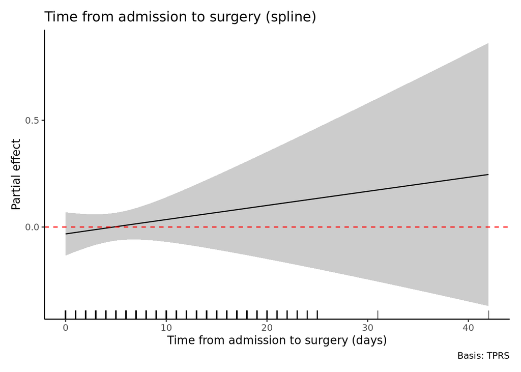

```
# A tibble: 1 × 5
  component             variance  std_dev lower_ci      upper_ci
  <chr>                    <dbl>    <dbl>    <dbl>         <dbl>
1 s(futime_adm_surg) 0.000000661 0.000813 3.36e-18 196530511543.
```

**Model with variable to predict: exitus in 7 days after surgery**

```
Family: binomial
Link function: logit

Formula:
exitus_7days_bl ~ s(futime_adm_surg, bs = "tp")

Parametric coefficients:
            Estimate Std. Error z value Pr(>|z|)
(Intercept) -3.49924    0.06846  -51.12   <2e-16 ***
---
Signif. codes:  0 '***' 0.001 '**' 0.01 '*' 0.05 '.' 0.1 ' ' 1

Approximate significance of smooth terms:
                     edf Ref.df Chi.sq p-value
s(futime_adm_surg) 1.007  1.013   0.18   0.682

R-sq.(adj) =  -0.000107   Deviance explained = 0.00952%
-REML = 996.46  Scale est. = 1         n = 7497
```

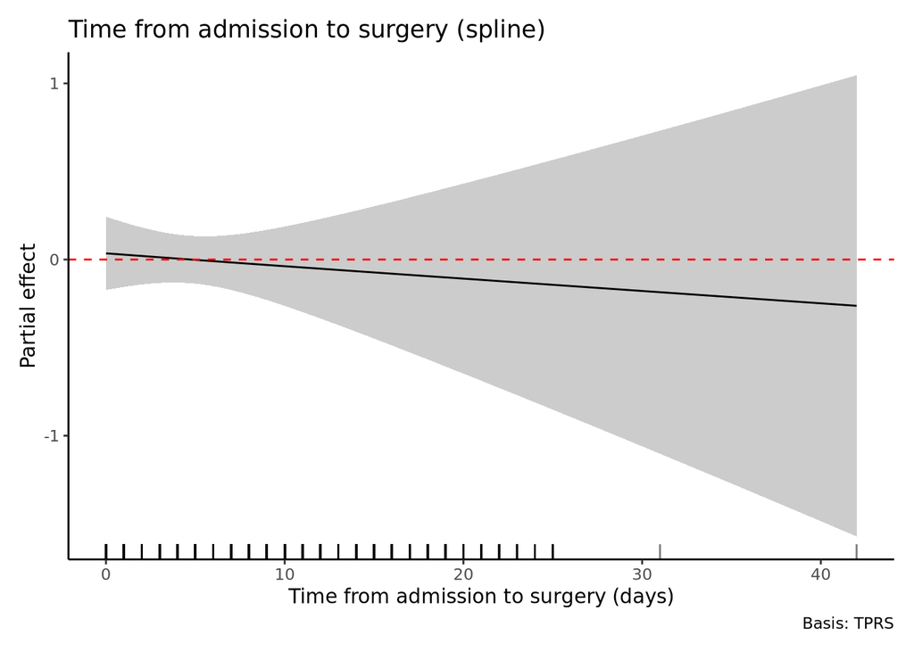

```
# A tibble: 1 × 5
  component            variance std_dev lower_ci upper_ci
  <chr>                   <dbl>   <dbl>    <dbl>    <dbl>
1 s(futime_adm_surg) 0.00000231 0.00152 2.62e-20  8.83e13
```

**Model with variable to predict: exitus in 30 days after surgery**

```
Family: binomial
Link function: logit

Formula:
exitus_30days_bl ~ s(futime_adm_surg, bs = "tp")

Parametric coefficients:
            Estimate Std. Error z value Pr(>|z|)
(Intercept) -2.60085    0.04555   -57.1   <2e-16 ***
---
Signif. codes:  0 '***' 0.001 '**' 0.01 '*' 0.05 '.' 0.1 ' ' 1

Approximate significance of smooth terms:
                     edf Ref.df Chi.sq p-value
s(futime_adm_surg) 1.002  1.003  0.176   0.676

R-sq.(adj) =  -0.00011   Deviance explained = 0.00473%
-REML = 1888.2  Scale est. = 1         n = 7497
```

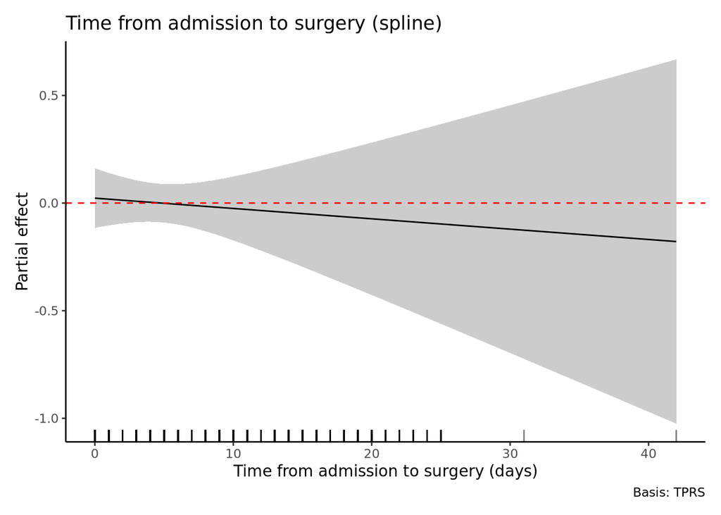

```
# A tibble: 1 × 5
  component             variance  std_dev lower_ci upper_ci
  <chr>                    <dbl>    <dbl>    <dbl>    <dbl>
1 s(futime_adm_surg) 0.000000266 0.000516 1.58e-19  1.68e12
```

###### Generalized Additive Mixed Model (GAMM)

**Model with variable to predict: exitus in hospital**

```
Family: binomial
Link function: logit

Formula:
exitus_hosp_bl ~ s(futime_adm_surg, bs = "tp") + s(hospital_st,
    bs = "re")

Parametric coefficients:
            Estimate Std. Error z value Pr(>|z|)
(Intercept) -1.78625    0.04135   -43.2   <2e-16 ***
---
Signif. codes:  0 '***' 0.001 '**' 0.01 '*' 0.05 '.' 0.1 ' ' 1

Approximate significance of smooth terms:
                     edf Ref.df Chi.sq p-value
s(futime_adm_surg) 1.008  1.016  0.081   0.793
s(hospital_st)     2.680  9.000  3.823   0.170

R-sq.(adj) =  0.000435   Deviance explained = 0.118%
-REML = 2792.6  Scale est. = 1         n = 6777
```

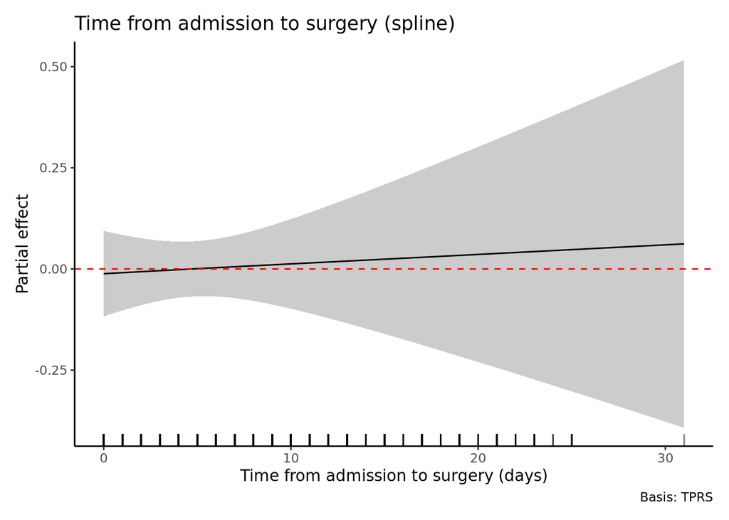

```
# A tibble: 2 × 5
  component             variance  std_dev lower_ci upper_ci
  <chr>                    <dbl>    <dbl>    <dbl>    <dbl>
1 s(futime_adm_surg) 0.000000715 0.000846 2.81e-18 2.54e+11
2 s(hospital_st)     0.00509     0.0714   1.52e- 2 3.35e- 1
[1] "ICC ajusted: 0.00155 with lower_ci95=-0.02056 and upper_ci95=0.02271"
```

```
[1] "Median odds ratio (MOR): 1.07045"
```

```
[1] "MOR with bootsrapping: 1.19175 with lower_ci95=1.09822 and upper_ci95=1.33378"
```

**Model with variable to predict: exitus in 7 days after surgery**

```
Family: binomial
Link function: logit

Formula:
exitus_7days_bl ~ s(futime_adm_surg, bs = "tp") + s(hospital_st,
    bs = "re")

Parametric coefficients:
            Estimate Std. Error z value Pr(>|z|)
(Intercept) -3.47371    0.07118   -48.8   <2e-16 ***
---
Signif. codes:  0 '***' 0.001 '**' 0.01 '*' 0.05 '.' 0.1 ' ' 1

Approximate significance of smooth terms:
                        edf Ref.df Chi.sq p-value
s(futime_adm_surg) 1.001157  1.002  0.445   0.506
s(hospital_st)     0.001948  9.000  0.002   0.598

R-sq.(adj) =  -7.66e-05   Deviance explained = 0.025%
-REML = 918.74  Scale est. = 1         n = 6777
```

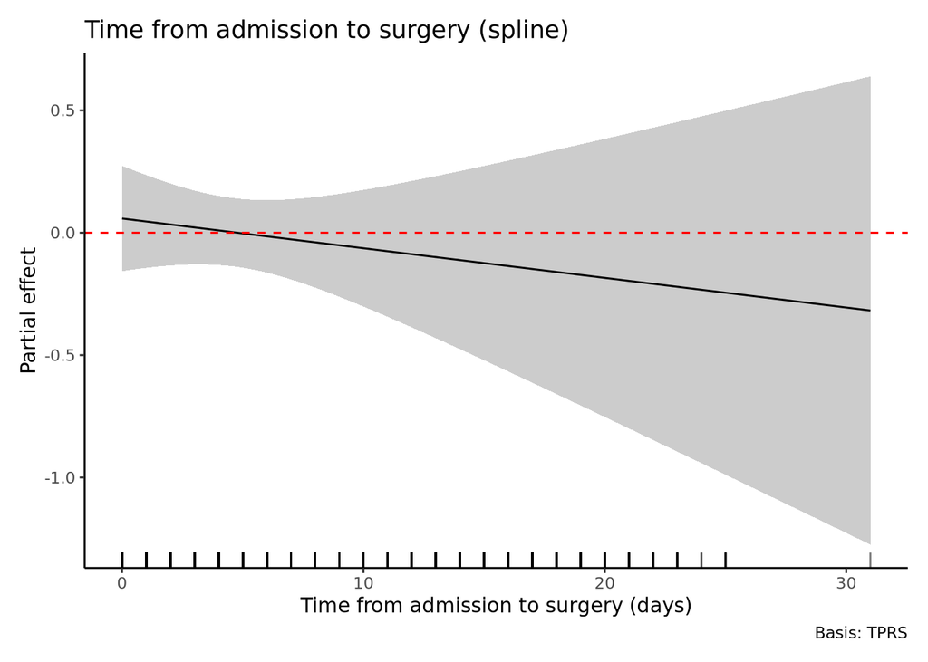

```
# A tibble: 2 × 5
  component             variance  std_dev lower_ci upper_ci
  <chr>                    <dbl>    <dbl>    <dbl>    <dbl>
1 s(futime_adm_surg) 0.000000491 0.000701 9.98e-30  4.92e22
2 s(hospital_st)     0.0000109   0.00331  2.47e-35  4.44e29
[1] "ICC ajusted: 0 with lower_ci95=-0.001 and upper_ci95=0.00101"
```

```
[1] "Median odds ratio (MOR): 1.00316"
```

```
[1] "MOR with bootsrapping: 1.00675 with lower_ci95=1.00363 and upper_ci95=1.01104"
```

**Model with variable to predict: exitus in 30 days after surgery**

```
Family: binomial
Link function: logit

Formula:
exitus_30days_bl ~ s(futime_adm_surg, bs = "tp") + s(hospital_st,
    bs = "re")

Parametric coefficients:
            Estimate Std. Error z value Pr(>|z|)
(Intercept) -2.58924    0.05931  -43.66   <2e-16 ***
---
Signif. codes:  0 '***' 0.001 '**' 0.01 '*' 0.05 '.' 0.1 ' ' 1

Approximate significance of smooth terms:
                     edf Ref.df Chi.sq p-value
s(futime_adm_surg) 1.002  1.003  0.372   0.543
s(hospital_st)     3.185  9.000  5.010   0.117

R-sq.(adj) =  0.000679   Deviance explained = 0.248%
-REML = 1721.4  Scale est. = 1         n = 6777
```

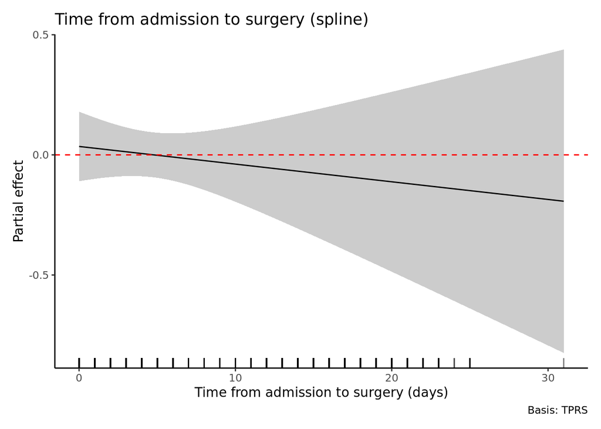

```
# A tibble: 2 × 5
  component             variance  std_dev lower_ci upper_ci
  <chr>                    <dbl>    <dbl>    <dbl>    <dbl>
1 s(futime_adm_surg) 0.000000289 0.000538 1.78e-20 1.63e+13
2 s(hospital_st)     0.0124      0.112    3.12e- 2 3.98e- 1
[1] "ICC ajusted: 0.00377 with lower_ci95=-0.03107 and upper_ci95=0.03633"
```

```
[1] "Median odds ratio (MOR): 1.11229"
```

```
[1] "MOR with bootsrapping: 1.25866 with lower_ci95=1.13526 and upper_ci95=1.45867"
```

##### Adjusted mortality by time to surgery (multivariate models)

**Model with variable to predict: exitus in hospital**

```
Family: binomial
Link function: logit

Formula:
exitus_hosp_bl ~ s(futime_adm_surg, bs = "tp") + sex_cd + socecon_lvl_cd +
    surgical_procedure_cd + anesthesia_type_cd + icu_admission_bl +
    anticoagulant_status_bl + antiaggregant_status_bl + chronic_kidney_disease_bl +
    tobacco_copd_bl + depression_bl + serious_mental_illness_bl +
    alcohol_abuse_bl + obesity_overweight_bl + osteoporosis_osteopenia_bl +
    dementia_bl + diabetes_bl + liver_disease_bl + pancreatic_disease_bl +
    inflamatory_bowel_disease_bl + rheumatology_disease_bl +
    spinal_cord_disease_injury_bl + serious_neurological_disease_bl +
    parkinson_huntington_diseases_bl + seizure_disorder_convulsions_bl +
    congestive_heart_failure_bl + coronary_artery_disease_bl +
    cerebrovascular_disease_bl + peripheral_vascular_disease_bl +
    traumatic_brain_injury_bl + amputee_bl + year + month + weekday +
    age_group + hospital_admission_type_cd + previous_hospital_admission_bl +
    s(hospital_st, bs = "re")

Parametric coefficients:
                                   Estimate Std. Error z value Pr(>|z|)
(Intercept)                      -2.2100864  0.4717754  -4.685  2.8e-06 ***
sex_cdmale                        0.0300573  0.2612891   0.115   0.9084
sex_cdfemale                      0.1123657  0.2612101   0.430   0.6671
socecon_lvl_cd2                   0.4634119  0.3195762   1.450   0.1470
socecon_lvl_cd3                   0.5902327  0.3089455   1.910   0.0561 .
socecon_lvl_cd4                   0.6297206  0.3091506   2.037   0.0417 *
socecon_lvl_cd5                   0.6232116  0.3166263   1.968   0.0490 *
surgical_procedure_cdPartial     -0.0337486  0.2208552  -0.153   0.8785
surgical_procedure_cdPinning      0.0114279  0.1791293   0.064   0.9491
surgical_procedure_cdOther        0.0474771  0.1435584   0.331   0.7409
anesthesia_type_cd1              -0.1156359  0.0842035  -1.373   0.1697
anesthesia_type_cd2              -0.1574158  0.0857316  -1.836   0.0663 .
icu_admission_bl                 -0.0633662  0.0742187  -0.854   0.3932
anticoagulant_status_bl          -0.1103363  0.1745972  -0.632   0.5274
antiaggregant_status_bl          -0.0625913  0.1625708  -0.385   0.7002
chronic_kidney_disease_bl        -0.0386976  0.1205272  -0.321   0.7482
tobacco_copd_bl                   0.0235769  0.1165014   0.202   0.8396
depression_bl                     0.0411244  0.1124378   0.366   0.7145
serious_mental_illness_bl        -0.0030821  0.1168817  -0.026   0.9790
```

[output cut: 47 more lines]

```
hospital_admission_type_cd2      -0.0738351  0.1127813  -0.655   0.5127
hospital_admission_type_cd3      -0.1417680  0.1134683  -1.249   0.2115
hospital_admission_type_cd4      -0.0229925  0.1282175  -0.179   0.8577
hospital_admission_type_cd5      -0.1531548  0.1356603  -1.129   0.2589
previous_hospital_admission_bl   -0.0072098  0.0712130  -0.101   0.9194
---
Signif. codes:  0 '***' 0.001 '**' 0.01 '*' 0.05 '.' 0.1 ' ' 1

Approximate significance of smooth terms:
                     edf Ref.df Chi.sq p-value
s(futime_adm_surg) 1.006  1.011  0.224   0.644
s(hospital_st)     2.843  9.000  4.139   0.158

R-sq.(adj) =  -0.00176   Deviance explained = 1.14%
-REML = 2848.5  Scale est. = 1         n = 6777
```

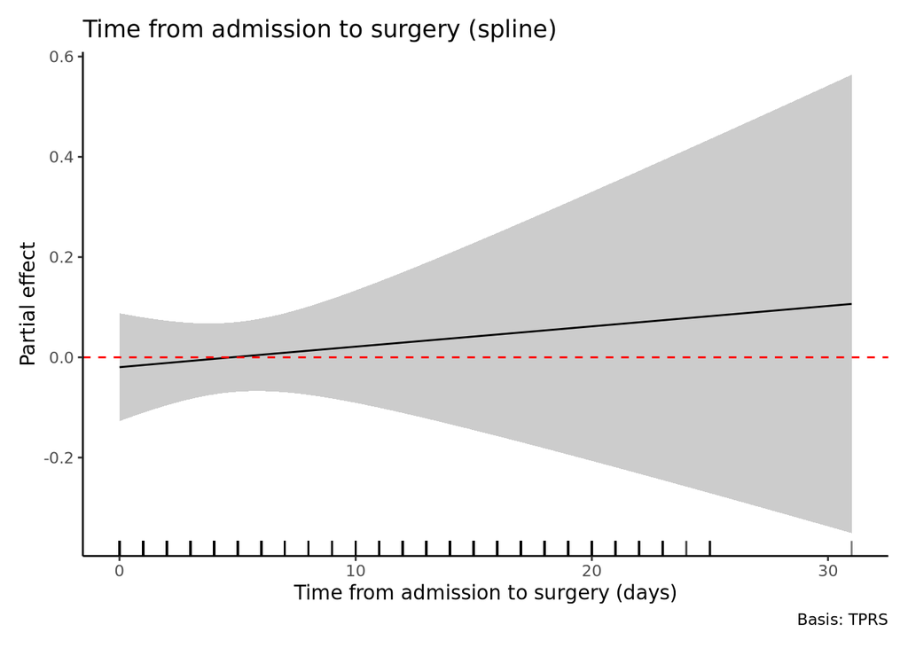

```
# A tibble: 2 × 5
  component             variance  std_dev lower_ci upper_ci
  <chr>                    <dbl>    <dbl>    <dbl>    <dbl>
1 s(futime_adm_surg) 0.000000532 0.000730 3.42e-18 1.56e+11
2 s(hospital_st)     0.00565     0.0751   1.74e- 2 3.25e- 1
```

```
[1] "ICC ajusted: 0.00171 with lower_ci95=-0.02158 and upper_ci95=0.02397"
```

```
[1] "Median odds ratio (MOR): 1.07431"
```

```
[1] "MOR with bootsrapping: 1.20602 with lower_ci95=1.1002 and upper_ci95=1.34093"
```

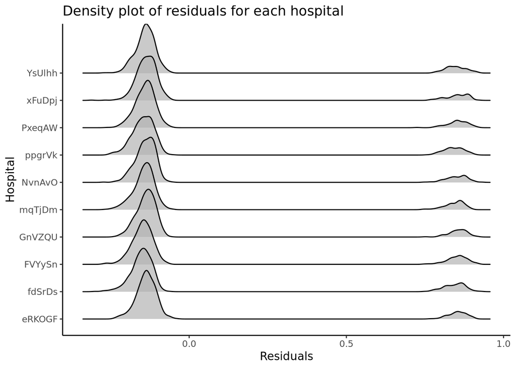

**Model with variable to predict: exitus in 7 days after surgery**

```
Family: binomial
Link function: logit

Formula:
exitus_7days_bl ~ s(futime_adm_surg, bs = "tp") + sex_cd + socecon_lvl_cd +
    surgical_procedure_cd + anesthesia_type_cd + icu_admission_bl +
    anticoagulant_status_bl + antiaggregant_status_bl + chronic_kidney_disease_bl +
    tobacco_copd_bl + depression_bl + serious_mental_illness_bl +
    alcohol_abuse_bl + obesity_overweight_bl + osteoporosis_osteopenia_bl +
    dementia_bl + diabetes_bl + liver_disease_bl + pancreatic_disease_bl +
    inflamatory_bowel_disease_bl + rheumatology_disease_bl +
    spinal_cord_disease_injury_bl + serious_neurological_disease_bl +
    parkinson_huntington_diseases_bl + seizure_disorder_convulsions_bl +
    congestive_heart_failure_bl + coronary_artery_disease_bl +
    cerebrovascular_disease_bl + peripheral_vascular_disease_bl +
    traumatic_brain_injury_bl + amputee_bl + year + month + weekday +
    age_group + hospital_admission_type_cd + previous_hospital_admission_bl +
    s(hospital_st, bs = "re")

Parametric coefficients:
                                   Estimate Std. Error z value Pr(>|z|)
(Intercept)                      -4.542e+00  1.331e+00  -3.413 0.000643 ***
sex_cdmale                        6.082e-01  7.254e-01   0.838 0.401766
sex_cdfemale                      7.193e-01  7.247e-01   0.993 0.320899
socecon_lvl_cd2                   1.256e+00  1.029e+00   1.221 0.222055
socecon_lvl_cd3                   1.495e+00  1.013e+00   1.476 0.140055
socecon_lvl_cd4                   1.538e+00  1.013e+00   1.518 0.128985
socecon_lvl_cd5                   1.443e+00  1.024e+00   1.408 0.159001
surgical_procedure_cdPartial     -3.049e-01  4.269e-01  -0.714 0.475094
surgical_procedure_cdPinning     -5.091e-01  3.642e-01  -1.398 0.162191
surgical_procedure_cdOther       -2.617e-01  2.640e-01  -0.991 0.321527
anesthesia_type_cd1              -1.556e-01  1.744e-01  -0.892 0.372523
anesthesia_type_cd2              -1.209e-01  1.747e-01  -0.692 0.489040
icu_admission_bl                 -7.845e-01  1.798e-01  -4.363 1.28e-05 ***
anticoagulant_status_bl           2.523e-01  3.089e-01   0.817 0.413987
antiaggregant_status_bl           6.233e-03  3.194e-01   0.020 0.984429
chronic_kidney_disease_bl        -3.437e-01  2.836e-01  -1.212 0.225573
tobacco_copd_bl                   2.045e-01  2.251e-01   0.909 0.363476
depression_bl                    -2.286e-01  2.529e-01  -0.904 0.366061
serious_mental_illness_bl         1.536e-01  2.290e-01   0.671 0.502422
```

[output cut: 47 more lines]

```
hospital_admission_type_cd2      -1.489e-03  2.239e-01  -0.007 0.994696
hospital_admission_type_cd3      -8.460e-02  2.307e-01  -0.367 0.713809
hospital_admission_type_cd4       9.269e-03  2.557e-01   0.036 0.971084
hospital_admission_type_cd5      -4.620e-01  3.114e-01  -1.484 0.137910
previous_hospital_admission_bl   -1.682e-01  1.453e-01  -1.158 0.247050
---
Signif. codes:  0 '***' 0.001 '**' 0.01 '*' 0.05 '.' 0.1 ' ' 1

Approximate significance of smooth terms:
                        edf Ref.df Chi.sq p-value
s(futime_adm_surg) 1.001348  1.003  0.376   0.542
s(hospital_st)     0.002891  9.000  0.003   0.500

R-sq.(adj) =  0.00446   Deviance explained = 4.92%
-REML = 890.21  Scale est. = 1         n = 6777
```

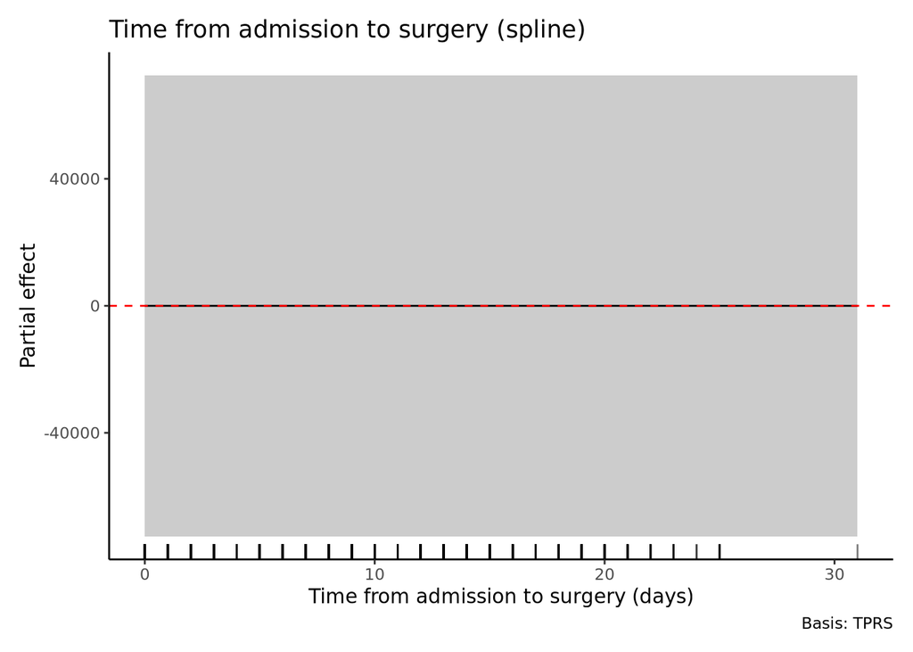

```
# A tibble: 2 × 5
  component             variance  std_dev lower_ci upper_ci
  <chr>                    <dbl>    <dbl>    <dbl>    <dbl>
1 s(futime_adm_surg) 0.000000600 0.000775 1.72e-31  3.48e24
2 s(hospital_st)     0.0000167   0.00409  1.70e-44  9.82e38
```

```
[1] "ICC ajusted: 1e-05 with lower_ci95=-0.00124 and upper_ci95=0.00125"
```

```
[1] "Median odds ratio (MOR): 1.00391"
```

```
[1] "MOR with bootsrapping: 1.00819 with lower_ci95=1.00413 and upper_ci95=1.0132"
```

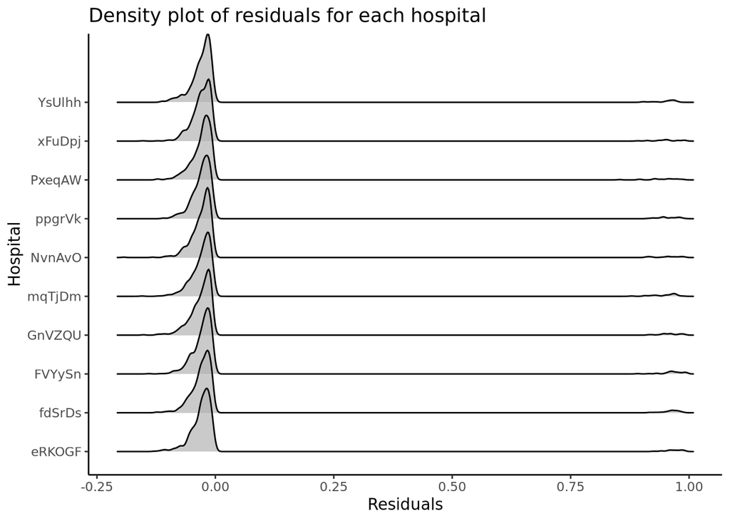

**Model with variable to predict: exitus in 30 days after surgery**

```
Family: binomial
Link function: logit

Formula:
exitus_30days_bl ~ s(futime_adm_surg, bs = "tp") + sex_cd + socecon_lvl_cd +
    surgical_procedure_cd + anesthesia_type_cd + icu_admission_bl +
    anticoagulant_status_bl + antiaggregant_status_bl + chronic_kidney_disease_bl +
    tobacco_copd_bl + depression_bl + serious_mental_illness_bl +
    alcohol_abuse_bl + obesity_overweight_bl + osteoporosis_osteopenia_bl +
    dementia_bl + diabetes_bl + liver_disease_bl + pancreatic_disease_bl +
    inflamatory_bowel_disease_bl + rheumatology_disease_bl +
    spinal_cord_disease_injury_bl + serious_neurological_disease_bl +
    parkinson_huntington_diseases_bl + seizure_disorder_convulsions_bl +
    congestive_heart_failure_bl + coronary_artery_disease_bl +
    cerebrovascular_disease_bl + peripheral_vascular_disease_bl +
    traumatic_brain_injury_bl + amputee_bl + year + month + weekday +
    age_group + hospital_admission_type_cd + previous_hospital_admission_bl +
    s(hospital_st, bs = "re")

Parametric coefficients:
                                  Estimate Std. Error z value Pr(>|z|)
(Intercept)                      -3.985158   0.800115  -4.981 6.33e-07 ***
sex_cdmale                        0.904766   0.515387   1.756  0.07917 .
sex_cdfemale                      0.948179   0.515321   1.840  0.06577 .
socecon_lvl_cd2                   0.788430   0.528266   1.492  0.13557
socecon_lvl_cd3                   0.977049   0.515424   1.896  0.05801 .
socecon_lvl_cd4                   1.005984   0.515625   1.951  0.05106 .
socecon_lvl_cd5                   1.007876   0.523940   1.924  0.05440 .
surgical_procedure_cdPartial     -0.263211   0.319978  -0.823  0.41074
surgical_procedure_cdPinning     -0.085820   0.245757  -0.349  0.72693
surgical_procedure_cdOther        0.003551   0.193220   0.018  0.98534
anesthesia_type_cd1              -0.159438   0.116828  -1.365  0.17234
anesthesia_type_cd2              -0.128730   0.117031  -1.100  0.27135
icu_admission_bl                 -0.242174   0.105244  -2.301  0.02139 *
anticoagulant_status_bl          -0.203244   0.250187  -0.812  0.41658
antiaggregant_status_bl          -0.052937   0.223666  -0.237  0.81291
chronic_kidney_disease_bl        -0.019618   0.166157  -0.118  0.90601
tobacco_copd_bl                   0.119406   0.155101   0.770  0.44138
depression_bl                    -0.087541   0.160738  -0.545  0.58601
serious_mental_illness_bl         0.036845   0.158748   0.232  0.81646
```

[output cut: 49 more lines]

```
hospital_admission_type_cd4      -0.045386   0.183245  -0.248  0.80438
hospital_admission_type_cd5      -0.039204   0.188090  -0.208  0.83489
previous_hospital_admission_bl   -0.007908   0.098129  -0.081  0.93577
---
Signif. codes:  0 '***' 0.001 '**' 0.01 '*' 0.05 '.' 0.1 ' ' 1

Approximate significance of smooth terms:
                     edf Ref.df Chi.sq p-value
s(futime_adm_surg) 1.001  1.003  0.229  0.6333
s(hospital_st)     3.978  9.000  7.218  0.0603 .
---
Signif. codes:  0 '***' 0.001 '**' 0.01 '*' 0.05 '.' 0.1 ' ' 1

R-sq.(adj) =  0.00163   Deviance explained = 2.56%
-REML = 1743.6  Scale est. = 1         n = 6777
```

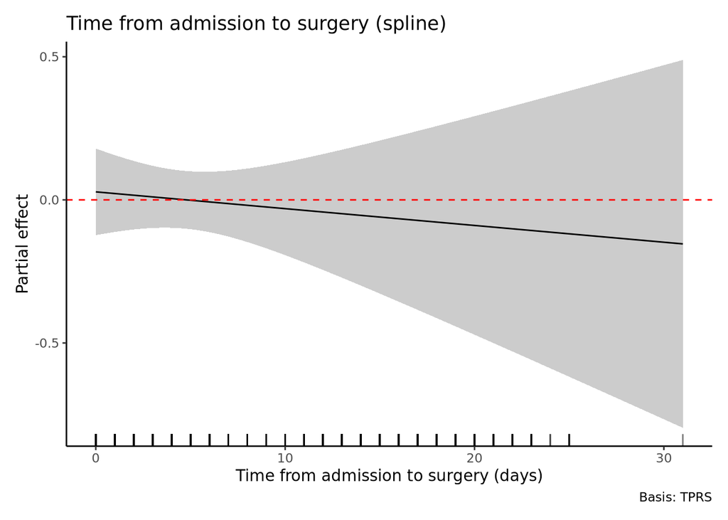

```
# A tibble: 2 × 5
  component             variance  std_dev lower_ci upper_ci
  <chr>                    <dbl>    <dbl>    <dbl>    <dbl>
1 s(futime_adm_surg) 0.000000280 0.000530 6.92e-21 4.05e+13
2 s(hospital_st)     0.0184      0.136    4.86e- 2 3.79e- 1
```

```
[1] "ICC ajusted: 0.00557 with lower_ci95=-0.03697 and upper_ci95=0.04476"
```

```
[1] "Median odds ratio (MOR): 1.13821"
```

```
[1] "MOR with bootsrapping: 1.3067 with lower_ci95=1.15357 and upper_ci95=1.52363"
```

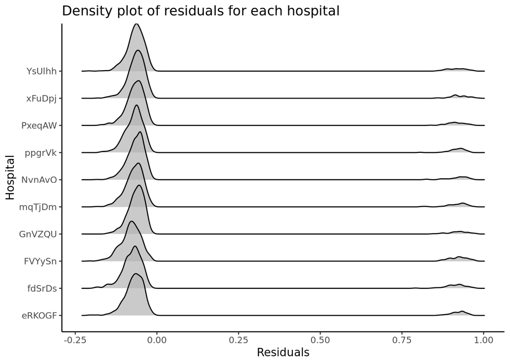

###### Performance comparison of multivariate GAMM models

```
# Comparison of Model Performance Indices

Name                                     | Model |  AIC (weights) | AICc (weights) |  BIC (weights) |     R2 |  RMSE | Sigma | Log_loss | Score_log | Score_spherical |   PCP
-----------------------------------------------------------------------------------------------------------------------------------------------------------------------------
Model 1: exitus in hospital              |   gam | 5666.1 (<.001) | 5667.9 (<.001) | 6189.9 (<.001) | -0.002 | 0.349 | 1.000 |    0.407 |  -150.780 |       1.476e-04 | 0.756
Model 2: exitus in 7 days after surgery  |   gam | 1885.1 (>.999) | 1886.7 (>.999) | 2376.3 (>.999) |  0.004 | 0.170 | 1.000 |    0.128 |    -6.220 |           0.005 | 0.942
Model 3: exitus in 30 days after surgery |   gam | 3502.6 (<.001) | 3504.4 (<.001) | 4030.5 (<.001) |  0.002 | 0.253 | 1.000 |    0.247 |   -34.331 |       4.597e-04 | 0.872
```

#### Adjusted unplanned readmissions by time to surgery (multivariate models)

**Model with variable to predict: unplanned readmission (for any cause) in the next 7 days after hospitalization**

```
Family: binomial
Link function: logit

Formula:
unplanned_readmission_7d_bl ~ s(futime_adm_surg, bs = "tp") +
    sex_cd + socecon_lvl_cd + surgical_procedure_cd + anesthesia_type_cd +
    icu_admission_bl + anticoagulant_status_bl + antiaggregant_status_bl +
    chronic_kidney_disease_bl + tobacco_copd_bl + depression_bl +
    serious_mental_illness_bl + alcohol_abuse_bl + obesity_overweight_bl +
    osteoporosis_osteopenia_bl + dementia_bl + diabetes_bl +
    liver_disease_bl + pancreatic_disease_bl + inflamatory_bowel_disease_bl +
    rheumatology_disease_bl + spinal_cord_disease_injury_bl +
    serious_neurological_disease_bl + parkinson_huntington_diseases_bl +
    seizure_disorder_convulsions_bl + congestive_heart_failure_bl +
    coronary_artery_disease_bl + cerebrovascular_disease_bl +
    peripheral_vascular_disease_bl + traumatic_brain_injury_bl +
    amputee_bl + year + month + weekday + age_group + hospital_admission_type_cd +
    previous_hospital_admission_bl + s(hospital_st, bs = "re")

Parametric coefficients:
                                  Estimate Std. Error z value Pr(>|z|)
(Intercept)                      -3.626821   0.768978  -4.716  2.4e-06 ***
sex_cdmale                       -0.157771   0.404022  -0.391   0.6962
sex_cdfemale                     -0.044707   0.403485  -0.111   0.9118
socecon_lvl_cd2                   0.880257   0.529682   1.662   0.0965 .
socecon_lvl_cd3                   0.600660   0.519834   1.155   0.2479
socecon_lvl_cd4                   0.756921   0.519260   1.458   0.1449
socecon_lvl_cd5                   0.360374   0.537900   0.670   0.5029
surgical_procedure_cdPartial      0.295703   0.340196   0.869   0.3847
surgical_procedure_cdPinning      0.301600   0.280807   1.074   0.2828
surgical_procedure_cdOther        0.110979   0.234783   0.473   0.6364
anesthesia_type_cd1              -0.259168   0.145401  -1.782   0.0747 .
anesthesia_type_cd2               0.248871   0.131422   1.894   0.0583 .
icu_admission_bl                 -0.107866   0.119795  -0.900   0.3679
anticoagulant_status_bl          -0.053981   0.273704  -0.197   0.8437
antiaggregant_status_bl           0.312023   0.227221   1.373   0.1697
chronic_kidney_disease_bl         0.345278   0.171371   2.015   0.0439 *
tobacco_copd_bl                  -0.120067   0.195738  -0.613   0.5396
depression_bl                    -0.052933   0.187173  -0.283   0.7773
serious_mental_illness_bl         0.100128   0.179449   0.558   0.5769
```

[output cut: 47 more lines]

```
hospital_admission_type_cd2       0.091643   0.170811   0.537   0.5916
hospital_admission_type_cd3      -0.076681   0.177256  -0.433   0.6653
hospital_admission_type_cd4      -0.524669   0.241308  -2.174   0.0297 *
hospital_admission_type_cd5       0.202869   0.194152   1.045   0.2961
previous_hospital_admission_bl    0.180326   0.115963   1.555   0.1199
---
Signif. codes:  0 '***' 0.001 '**' 0.01 '*' 0.05 '.' 0.1 ' ' 1

Approximate significance of smooth terms:
                        edf Ref.df Chi.sq p-value
s(futime_adm_surg) 1.000701  1.001  0.320   0.572
s(hospital_st)     0.003623  9.000  0.003   0.577

R-sq.(adj) =  0.00428   Deviance explained = 3.48%
-REML = 1374.5  Scale est. = 1         n = 6777
```

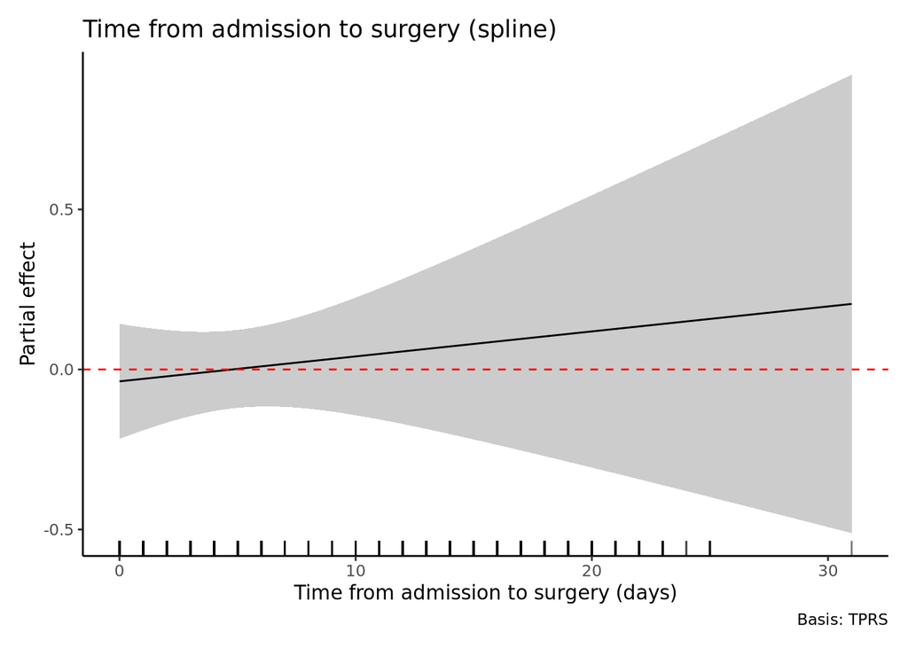

```
# A tibble: 2 × 5
  component             variance  std_dev lower_ci upper_ci
  <chr>                    <dbl>    <dbl>    <dbl>    <dbl>
1 s(futime_adm_surg) 0.000000169 0.000411 9.00e-37  1.87e29
2 s(hospital_st)     0.0000126   0.00355  2.20e-28  5.74e22
```

```
[1] "ICC ajusted: 0 with lower_ci95=-0.00108 and upper_ci95=0.00108"
```

```
[1] "Median odds ratio (MOR): 1.00339"
```

```
[1] "MOR with bootsrapping: 1.00815 with lower_ci95=1.00421 and upper_ci95=1.01306"
```

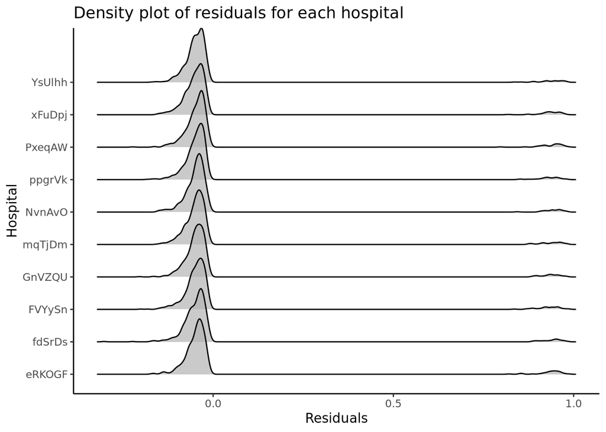

**Model with variable to predict: unplanned readmission (for any cause) in the next 30 days after hospitalization**

```
Family: binomial
Link function: logit

Formula:
unplanned_readmission_30d_bl ~ s(futime_adm_surg, bs = "tp") +
    sex_cd + socecon_lvl_cd + surgical_procedure_cd + anesthesia_type_cd +
    icu_admission_bl + anticoagulant_status_bl + antiaggregant_status_bl +
    chronic_kidney_disease_bl + tobacco_copd_bl + depression_bl +
    serious_mental_illness_bl + alcohol_abuse_bl + obesity_overweight_bl +
    osteoporosis_osteopenia_bl + dementia_bl + diabetes_bl +
    liver_disease_bl + pancreatic_disease_bl + inflamatory_bowel_disease_bl +
    rheumatology_disease_bl + spinal_cord_disease_injury_bl +
    serious_neurological_disease_bl + parkinson_huntington_diseases_bl +
    seizure_disorder_convulsions_bl + congestive_heart_failure_bl +
    coronary_artery_disease_bl + cerebrovascular_disease_bl +
    peripheral_vascular_disease_bl + traumatic_brain_injury_bl +
    amputee_bl + year + month + weekday + age_group + hospital_admission_type_cd +
    previous_hospital_admission_bl + s(hospital_st, bs = "re")

Parametric coefficients:
                                  Estimate Std. Error z value Pr(>|z|)
(Intercept)                      -1.659220   0.478111  -3.470  0.00052 ***
sex_cdmale                       -0.134821   0.284138  -0.474  0.63515
sex_cdfemale                     -0.199914   0.284804  -0.702  0.48272
socecon_lvl_cd2                  -0.530655   0.265458  -1.999  0.04561 *
socecon_lvl_cd3                  -0.519137   0.249158  -2.084  0.03720 *
socecon_lvl_cd4                  -0.519312   0.250029  -2.077  0.03780 *
socecon_lvl_cd5                  -0.616389   0.264950  -2.326  0.02000 *
surgical_procedure_cdPartial      0.675641   0.255747   2.642  0.00825 **
surgical_procedure_cdPinning      0.430825   0.225388   1.911  0.05594 .
surgical_procedure_cdOther        0.354403   0.190754   1.858  0.06318 .
anesthesia_type_cd1               0.103704   0.101284   1.024  0.30588
anesthesia_type_cd2               0.131510   0.101902   1.291  0.19686
icu_admission_bl                  0.032474   0.086335   0.376  0.70681
anticoagulant_status_bl           0.004273   0.198711   0.022  0.98285
antiaggregant_status_bl           0.274919   0.172285   1.596  0.11055
chronic_kidney_disease_bl        -0.073954   0.142817  -0.518  0.60458
tobacco_copd_bl                  -0.325656   0.153311  -2.124  0.03366 *
depression_bl                    -0.182164   0.142643  -1.277  0.20158
serious_mental_illness_bl        -0.130139   0.143327  -0.908  0.36388
```

[output cut: 47 more lines]

```
hospital_admission_type_cd2       0.113514   0.127762   0.888  0.37428
hospital_admission_type_cd3      -0.175424   0.135861  -1.291  0.19663
hospital_admission_type_cd4      -0.001278   0.152849  -0.008  0.99333
hospital_admission_type_cd5       0.159163   0.147087   1.082  0.27921
previous_hospital_admission_bl   -0.088502   0.083336  -1.062  0.28824
---
Signif. codes:  0 '***' 0.001 '**' 0.01 '*' 0.05 '.' 0.1 ' ' 1

Approximate significance of smooth terms:
                      edf Ref.df Chi.sq p-value
s(futime_adm_surg) 1.0044  1.009  0.039   0.852
s(hospital_st)     0.6901  9.000  0.746   0.373

R-sq.(adj) =  0.000143   Deviance explained = 1.74%
-REML = 2224.2  Scale est. = 1         n = 6777
```

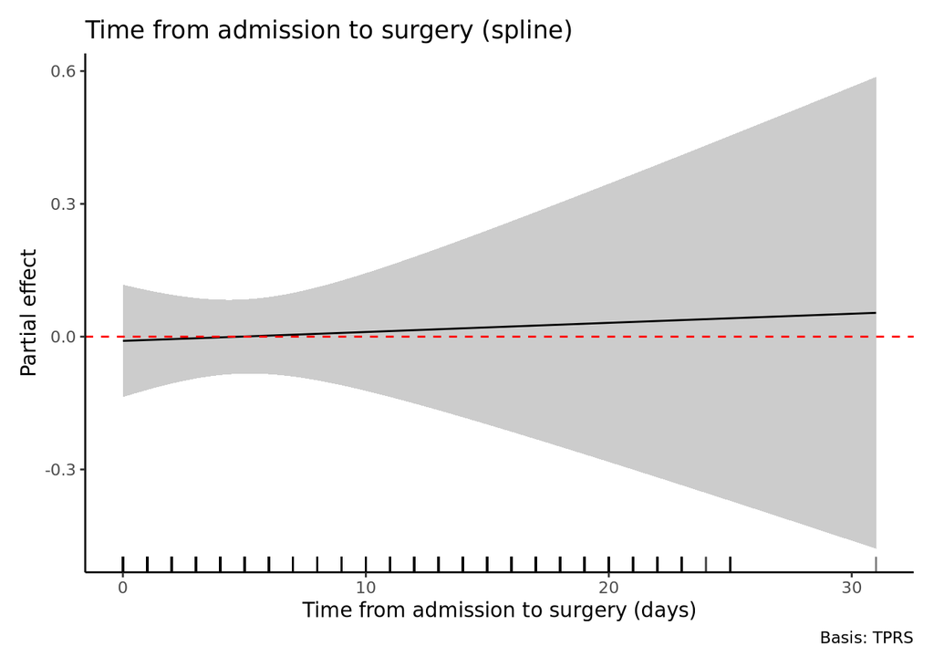

```
# A tibble: 2 × 5
  component             variance  std_dev lower_ci     upper_ci
  <chr>                    <dbl>    <dbl>    <dbl>        <dbl>
1 s(futime_adm_surg) 0.000000558 0.000747 7.07e-17 7888642472.
2 s(hospital_st)     0.00141     0.0375   8.15e- 5         17.3
```

```
[1] "ICC ajusted: 0.00043 with lower_ci95=-0.0111 and upper_ci95=0.0117"
```

```
[1] "Median odds ratio (MOR): 1.03644"
```

```
[1] "MOR with bootsrapping: 1.10133 with lower_ci95=1.04966 and upper_ci95=1.16565"
```

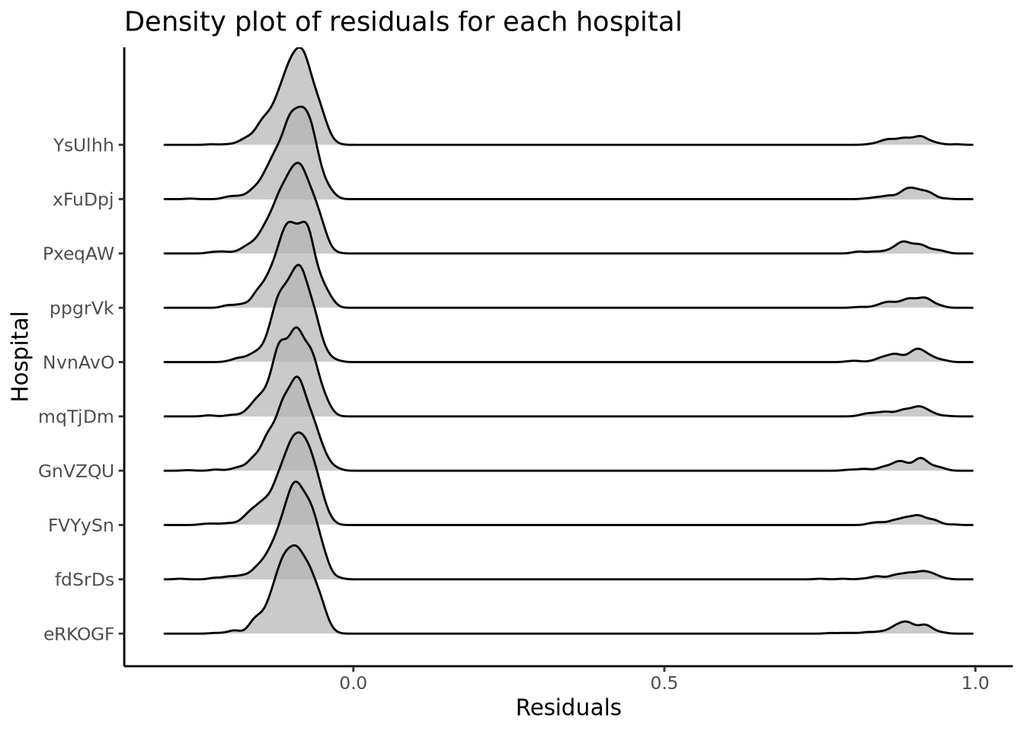

##### Performance comparison of multivariate GAMM models

```
# Comparison of Model Performance Indices

Name                                                                     | Model |  AIC (weights) | AICc (weights) |  BIC (weights) |        R2 |  RMSE | Sigma | Log_loss | Score_log | Score_spherical |   PCP
----------------------------------------------------------------------------------------------------------------------------------------------------------------------------------------------------------------
Model 1: unplanned readmission in the next 7 days after hospitalization  |   gam | 2781.6 (>.999) | 2783.1 (>.999) | 3272.8 (>.999) |     0.004 | 0.218 | 1.000 |    0.195 |   -18.122 |           0.002 | 0.905
Model 2: unplanned readmission in the next 30 days after hospitalization |   gam | 4438.6 (<.001) | 4440.3 (<.001) | 4938.9 (<.001) | 1.431e-04 | 0.297 | 1.000 |    0.317 |   -69.520 |       3.116e-04 | 0.824
```